# Groceries dataset

Cho dữ liệu **ItemList.xlsx**  
Yêu cầu: Đọc dữ liệu, chuẩn hóa dữ liệu (nếu cần) và chọn một **thuật toán thích hợp** trong nhóm Association rule learning để tính toán mức độ kết hợp giữa các item.

1. Áp dụng thuật toán (tự lựa chọn các tham số phù hợp cho thuật toán, lưu ý với số lượng transaction càng nhiều thì các ngưỡng càng nhỏ, gợi ý: min_support = 0.001). In kết quả. Vẽ biểu đồ.
2. Tìm kiếm thông tin từ kết quả: trong thông tin kết quả có 'sausage' không? Nếu có thì 'sausage' kết hợp với item nào?
3. Cho biết 15 sản phẩm được mua nhiều nhất. Vẽ biểu đồ.
4. Cho biết 15 sản phẩm được mua ít nhất. Vẽ biểu đồ.

**---------------------------------------------------- DATA OVERVIEW ----------------------------------------------------------**

```python
import pandas as pd
data = pd.read_excel('du lieu cung cap/ItemList.xlsx', header = None)
```

```python
data.info()
```

```
<class 'pandas.core.frame.DataFrame'>
RangeIndex: 14963 entries, 0 to 14962
Data columns (total 11 columns):
0     14963 non-null object
1     14963 non-null object
2     4883 non-null object
3     2185 non-null object
4     795 non-null object
5     451 non-null object
6     276 non-null object
7     196 non-null object
8     51 non-null object
9     1 non-null object
10    1 non-null object
dtypes: object(11)
memory usage: 1.3+ MB
```

```python
print('Number of rows:',data.shape[0])
print('Number of columns:',data.shape[1])
```

```
Number of rows: 14963
Number of columns: 11
```

```python
data.head()
```

|  | 0 | 1 | 2 | 3 | 4 | 5 | 6 | 7 | 8 | 9 | 10 |
| --- | --- | --- | --- | --- | --- | --- | --- | --- | --- | --- | --- |
| 0 | sausage | whole milk | semi-finished bread | yogurt | NaN | NaN | NaN | NaN | NaN | NaN | NaN |
| 1 | whole milk | pastry | salty snack | NaN | NaN | NaN | NaN | NaN | NaN | NaN | NaN |
| 2 | canned beer | misc. beverages | NaN | NaN | NaN | NaN | NaN | NaN | NaN | NaN | NaN |
| 3 | sausage | hygiene articles | NaN | NaN | NaN | NaN | NaN | NaN | NaN | NaN | NaN |
| 4 | soda | pickled vegetables | NaN | NaN | NaN | NaN | NaN | NaN | NaN | NaN | NaN |

**1. Áp dụng thuật toán (tự lựa chọn các tham số phù hợp cho thuật toán, lưu ý với số lượng transaction càng nhiều thì các ngưỡng càng nhỏ, gợi ý: min_support = 0.001). In kết quả. Vẽ biểu đồ.**

**---------------------------------------------------- 1. APRIORI ----------------------------------------------------------**

**Xử lý inputs**

```python
records = []
for i in range(0, data.shape[0]):
    records.append([str(data.values[i,j]) for j in range(0, data.shape[1])])
```

```python
from mlxtend.preprocessing import TransactionEncoder
te = TransactionEncoder()
te_ary = te.fit(records).transform(records)
df = pd.DataFrame(te_ary, columns=te.columns_)
df.shape
```

```
(14963, 168)
```

```python
df.info()
```

```
<class 'pandas.core.frame.DataFrame'>
RangeIndex: 14963 entries, 0 to 14962
Columns: 168 entries, Instant food products to zwieback
dtypes: bool(168)
memory usage: 2.4 MB
```

```python
df.head()
```

|  | Instant food products | UHT-milk | abrasive cleaner | artif. sweetener | baby cosmetics | bags | baking powder | bathroom cleaner | beef | berries | ... | turkey | vinegar | waffles | whipped/sour cream | whisky | white bread | white wine | whole milk | yogurt | zwieback |
| --- | --- | --- | --- | --- | --- | --- | --- | --- | --- | --- | --- | --- | --- | --- | --- | --- | --- | --- | --- | --- | --- |
| 0 | False | False | False | False | False | False | False | False | False | False | ... | False | False | False | False | False | False | False | True | True | False |
| 1 | False | False | False | False | False | False | False | False | False | False | ... | False | False | False | False | False | False | False | True | False | False |
| 2 | False | False | False | False | False | False | False | False | False | False | ... | False | False | False | False | False | False | False | False | False | False |
| 3 | False | False | False | False | False | False | False | False | False | False | ... | False | False | False | False | False | False | False | False | False | False |
| 4 | False | False | False | False | False | False | False | False | False | False | ... | False | False | False | False | False | False | False | False | False | False |

5 rows × 168 columns

```python
df = df.drop(['nan'], axis=1)
```

```python
df.shape
```

```
(14963, 167)
```

**Nhận xét data:** Số Transactions lớn, nhiều items

```python
from mlxtend.frequent_patterns import apriori
frequent_itemsets = apriori(df, min_support=0.001, use_colnames=True)
pd.options.display.max_rows = 1000
display(frequent_itemsets.sort_values(by='support',ascending=False))
pd.options.display.max_rows = 15
```

|  | support | itemsets |
| --- | --- | --- |
| 146 | 0.157923 | (whole milk) |
| 90 | 0.122101 | (other vegetables) |
| 109 | 0.110005 | (rolls/buns) |
| 123 | 0.097106 | (soda) |
| 147 | 0.085879 | (yogurt) |
| 110 | 0.069572 | (root vegetables) |
| 139 | 0.067767 | (tropical fruit) |
| 10 | 0.060683 | (bottled water) |
| 115 | 0.060349 | (sausage) |
| 28 | 0.053131 | (citrus fruit) |
| 93 | 0.051728 | (pastry) |
| 97 | 0.049054 | (pip fruit) |
| 118 | 0.047584 | (shopping bags) |
| 18 | 0.046916 | (canned beer) |
| 9 | 0.045312 | (bottled beer) |
| 143 | 0.043708 | (whipped/sour cream) |
| 84 | 0.038896 | (newspapers) |
| 52 | 0.037760 | (frankfurter) |
| 12 | 0.037626 | (brown bread) |
| 99 | 0.037091 | (pork) |
| 45 | 0.037091 | (domestic eggs) |
| 13 | 0.035220 | (butter) |
| 58 | 0.034017 | (fruit/vegetable juice) |
| 6 | 0.033950 | (beef) |
| 37 | 0.033683 | (curd) |
| 77 | 0.032213 | (margarine) |
| 32 | 0.031611 | (coffee) |
| 57 | 0.028002 | (frozen vegetables) |
| 25 | 0.027869 | (chicken) |
| 144 | 0.023993 | (white bread) |

[output cut: 720 more lines]

```python
frequent_itemsets.shape
```

```
(750, 2)
```

```python
from mlxtend.frequent_patterns import association_rules
rule_confidence = association_rules(frequent_itemsets, metric="confidence", min_threshold=0.1)
rule_confidence.shape
```

```
(130, 9)
```

```python
rule_confidence.head()
```

|  | antecedents | consequents | antecedent support | consequent support | support | confidence | lift | leverage | conviction |
| --- | --- | --- | --- | --- | --- | --- | --- | --- | --- |
| 0 | (UHT-milk) | (other vegetables) | 0.021386 | 0.122101 | 0.002139 | 0.100000 | 0.818993 | -0.000473 | 0.975443 |
| 1 | (UHT-milk) | (whole milk) | 0.021386 | 0.157923 | 0.002540 | 0.118750 | 0.751949 | -0.000838 | 0.955549 |
| 2 | (beef) | (whole milk) | 0.033950 | 0.157923 | 0.004678 | 0.137795 | 0.872548 | -0.000683 | 0.976656 |
| 3 | (berries) | (other vegetables) | 0.021787 | 0.122101 | 0.002673 | 0.122699 | 1.004899 | 0.000013 | 1.000682 |
| 4 | (berries) | (whole milk) | 0.021787 | 0.157923 | 0.002272 | 0.104294 | 0.660414 | -0.001168 | 0.940127 |

```python
rule_lift = association_rules(frequent_itemsets, metric="lift", min_threshold=1.2)
rule_lift.shape
```

```
(88, 9)
```

```python
rule_lift.head()
```

|  | antecedents | consequents | antecedent support | consequent support | support | confidence | lift | leverage | conviction |
| --- | --- | --- | --- | --- | --- | --- | --- | --- | --- |
| 0 | (brown bread) | (beef) | 0.037626 | 0.033950 | 0.001537 | 0.040853 | 1.203301 | 0.000260 | 1.007196 |
| 1 | (beef) | (brown bread) | 0.033950 | 0.037626 | 0.001537 | 0.045276 | 1.203301 | 0.000260 | 1.008012 |
| 2 | (beef) | (frozen vegetables) | 0.033950 | 0.028002 | 0.001270 | 0.037402 | 1.335656 | 0.000319 | 1.009764 |
| 3 | (frozen vegetables) | (beef) | 0.028002 | 0.033950 | 0.001270 | 0.045346 | 1.335656 | 0.000319 | 1.011937 |
| 4 | (margarine) | (beef) | 0.032213 | 0.033950 | 0.001403 | 0.043568 | 1.283297 | 0.000310 | 1.010056 |

**2. Tìm kiếm thông tin từ kết quả: trong thông tin kết quả có 'sausage' không? Nếu có thì 'sausage' kết hợp với item nào?**

```python
for row in rule_lift.iterrows():
    if "sausage" in row[1][0]:
        print(row)
```

[output not shown]

[output cut: 165 more lines]

[output not shown]

**---------------------------------------------------- End APRIORI ----------------------------------------------------------**

**---------------------------------------------------- 2. ECLAT ----------------------------------------------------------**

```python
import sys
from collections import defaultdict
import random
```

```python
# # source code from: http://codegist.net/snippet/python/eclatpy_evertheylen_python
def tidlists(transactions):
    tl = defaultdict(set)
    for tid, t in enumerate(transactions):
        for item in t:
            tl[item].add(tid)
    return list(tl.items())

class IntersectAll:
    def __and__(self, other):
        return other
IntersectAll = IntersectAll()

def eclat(items, minsup=0, minlen=1):
    frequent_itemsets = {(): IntersectAll}
    def recurse(items, prefix):
        while len(items) > 0:
            item, item_tidlist = items.pop()
            l = prefix + (item,)  # l is the (ordered) tuple of items we are looking for
            new_tidlist = frequent_itemsets[prefix] & item_tidlist
            if len(new_tidlist) >= minsup:  # add frequent_itemsets to the new frequent_itemsets
                frequent_itemsets[l] = new_tidlist

            # define the new l-conditional database
            new_items = []
            for new_item, _item_tidlist in items:
                new_item_tidlist = _item_tidlist & item_tidlist
                if len(new_item_tidlist) >= minsup:
                    new_items.append((new_item, new_item_tidlist))

            # recurse, with l as prefix
            recurse(new_items, l)

    recurse(items.copy(), ())
    return {k: len(v) for k, v in frequent_itemsets.items() if len(k) >= minlen}
```

```python
tl = tidlists(records)
len(tl)
```

```
168
```

```python
for i in range(len(tl)-1):
    if tl[i][0] == 'nan':
        print(i)
        del tl[i]
```

```
4
```

```python
eclat_result = eclat(tl, minsup=50, minlen=1)
eclat_result
```

```
{('Instant food products',): 60,
 ('UHT-milk',): 320,
 ('baking powder',): 121,
 ('beef',): 508,
 ('beef', 'whole milk'): 70,
 ('berries',): 326,
 ('beverages',): 248,
 ('bottled beer',): 678,
 ('bottled beer', 'other vegetables'): 70,
 ('bottled beer', 'rolls/buns'): 60,
 ('bottled beer', 'sausage'): 50,
 ('bottled beer', 'whole milk'): 107,
 ('bottled beer', 'yogurt'): 51,
 ('bottled water',): 908,
 ('bottled water', 'other vegetables'): 82,
 ('bottled water', 'rolls/buns'): 70,
 ('bottled water', 'root vegetables'): 52,
 ('bottled water', 'soda'): 72,
 ('bottled water', 'tropical fruit'): 53,
 ('bottled water', 'whole milk'): 107,
 ('bottled water', 'yogurt'): 57,
 ('brown bread',): 563,
 ('brown bread', 'rolls/buns'): 50,
 ('brown bread', 'whole milk'): 67,
 ('butter',): 527,
 ('butter', 'whole milk'): 70,
 ('butter milk',): 263,
 ('cake bar',): 92,
 ('candles',): 66,
 ('candy',): 215,
 ('canned beer',): 702,
 ('canned beer', 'whole milk'): 90,
 ('canned beer', 'yogurt'): 58,
 ('canned fish',): 115,
 ('canned vegetables',): 82,
 ('cat food',): 177,
 ('chewing gum',): 180,
 ('chicken',): 417,
 ('chicken', 'whole milk'): 51,
 ('chocolate',): 353,
```

[output cut: 140 more lines]

```
 ('tropical fruit', 'yogurt'): 78,
 ('turkey',): 80,
 ('vinegar',): 51,
 ('waffles',): 277,
 ('whipped/sour cream',): 654,
 ('whipped/sour cream', 'soda'): 51,
 ('whipped/sour cream', 'whole milk'): 69,
 ('white bread',): 359,
 ('white wine',): 175,
 ('whole milk',): 2363,
 ('whole milk', 'sausage'): 134,
 ('yogurt',): 1285,
 ('yogurt', 'sausage'): 86,
 ('yogurt', 'whole milk'): 167,
 ('zwieback',): 60}
```

```python
for k, v in eclat_result.items():
    if "sausage" in k:
        print(k, ":", v)
```

```
('bottled beer', 'sausage') : 50
('root vegetables', 'sausage') : 50
('other vegetables', 'sausage') : 90
('rolls/buns', 'sausage') : 80
('soda', 'sausage') : 89
('yogurt', 'sausage') : 86
('whole milk', 'sausage') : 134
('sausage',) : 903
```

**---------------------------------------------------- End ECLAT ----------------------------------------------------------**

```python
result = df.apply(pd.value_counts).fillna(0)
result
```

|  | Instant food products | UHT-milk | abrasive cleaner | artif. sweetener | baby cosmetics | bags | baking powder | bathroom cleaner | beef | berries | ... | turkey | vinegar | waffles | whipped/sour cream | whisky | white bread | white wine | whole milk | yogurt | zwieback |
| --- | --- | --- | --- | --- | --- | --- | --- | --- | --- | --- | --- | --- | --- | --- | --- | --- | --- | --- | --- | --- | --- |
| False | 14903 | 14643 | 14941 | 14934 | 14960 | 14959 | 14842 | 14946 | 14455 | 14637 | ... | 14883 | 14912 | 14686 | 14309 | 14955 | 14604 | 14788 | 12600 | 13678 | 14903 |
| True | 60 | 320 | 22 | 29 | 3 | 4 | 121 | 17 | 508 | 326 | ... | 80 | 51 | 277 | 654 | 8 | 359 | 175 | 2363 | 1285 | 60 |

2 rows × 167 columns

```python
df_true = result.iloc[1,:]
x = df_true.sort_values(ascending=False)
```

```python
ten_buy_most = x[:10]
ten_buy_most
```

```
whole milk          2363
other vegetables    1827
rolls/buns          1646
soda                1453
yogurt              1285
root vegetables     1041
tropical fruit      1014
bottled water        908
sausage              903
citrus fruit         795
Name: True, dtype: int64
```

```python
import numpy as np
pos = np.arange(len(ten_buy_most.values))
```

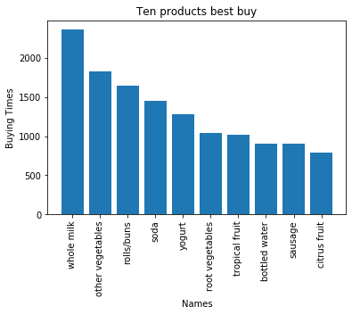

```python
import matplotlib.pyplot as plt
plt.bar(pos, ten_buy_most.values, align='center')
plt.xticks(pos, ten_buy_most.keys(), rotation='vertical')
plt.ylabel('Buying Times')
plt.xlabel('Names')
plt.title('Ten products best buy')
plt.show()
```

```python
df_true = result.iloc[1,:]
x1 = df_true.sort_values(ascending=True)
```

```python
ten_buy_less = x1[:10]
ten_buy_less
```

```
preservation products    1
kitchen utensil          1
baby cosmetics           3
bags                     4
frozen chicken           5
toilet cleaner           5
rubbing alcohol          5
make up remover          5
salad dressing           6
whisky                   8
Name: True, dtype: int64
```

```python
import numpy as np
pos = np.arange(len(ten_buy_less.values))
```

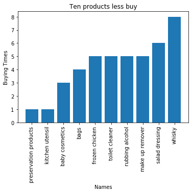

```python
import matplotlib.pyplot as plt
plt.bar(pos, ten_buy_less.values, align='center')
plt.xticks(pos, ten_buy_less.keys(), rotation='vertical')
plt.ylabel('Buying Times')
plt.xlabel('Names')
plt.title('Ten products less buy')
plt.show()
```